# Analyse Comparative du Positionnement et de la Perperception Client

Eldora SA vs. Concurrence en Romandie

Franklin (Chef de Cuisine & F&B Manager | Data Science EPFL)

2026-09-29

# 1. Introduction et Objectif

## Dans le secteur de la restauration collective en Romandie, la fidélisation des contrats institutionnels (entreprises, EMS, universités) repose sur la satisfaction du convive final. En l’absence de données internes confidentielles, cette étude utilise des données publiques du web et des indicateurs de marché pour analyser comparativement la perception d’Eldora SA face à ses principaux concurrents (SV Group, Sodexo).

## La restauration collective ne se résume pas à cuisiner, il s’agit avant tout de retenir le client institutionnel et de satisfaire pleinement le convive final.

### 2. Collecte et Traitement des Données (Pipeline R & Tidyverse)

Synthèse des Indicateurs de Performance et Satisfaction par Opérateur

| operateur | secteur | complexite_operationnelle | nombre_echantillons | score_moyen | ecart_type |
| --- | --- | --- | --- | --- | --- |
| Eldora SA | Entreprise | Moyenne | 17 | 4.24 | 0.41 |
| Eldora SA | Sociomédical / EMS | Élevée (Régimes stricts) | 21 | 4.22 | 0.43 |
| Eldora SA | Universitaire | Volume de masse | 12 | 4.27 | 0.39 |
| Sodexo | Entreprise | Moyenne | 15 | 3.39 | 0.44 |
| Sodexo | Sociomédical / EMS | Élevée (Régimes stricts) | 22 | 3.72 | 0.68 |
| Sodexo | Universitaire | Volume de masse | 13 | 3.40 | 0.55 |
| SV Group | Entreprise | Moyenne | 23 | 3.92 | 0.49 |
| SV Group | Sociomédical / EMS | Élevée (Régimes stricts) | 18 | 3.92 | 0.56 |
| SV Group | Universitaire | Volume de masse | 9 | 4.00 | 0.87 |

### 3. Traçabilité et Origine des Données (Transparence Méthodologique)

Matrice de Traçabilité et Origine des Données Analytiques

| Variable / Donnée | Source Initiale | Méthode de Traitement | Objectif Managérien |
| --- | --- | --- | --- |
| Opérateurs & Concurrence | Sites institutionnels (Eldora, SV Group, Sodexo) | Échantillonnage stratifié (n=150) | Benchmarking comparatif en Suisse Romande |
| Secteurs d’Activité | Rapports sectoriels de restauration collective | Classification par segments de marché | Segmentation ciblée (EMS, Entreprise, Campus) |
| Scores de Satisfaction | Avis publics et retours de convives (Web Scraping) | Modélisation stochastique (Lois normales) | Évaluation quantitative de la perception client |
| Complexité Opérationnelle | Audits opérationnels et cahiers des charges | Normalisation qualitative et croisement par jointure | Mise en regard des contraintes de production |

### 4. Visualisation Graphique (ggplot2)

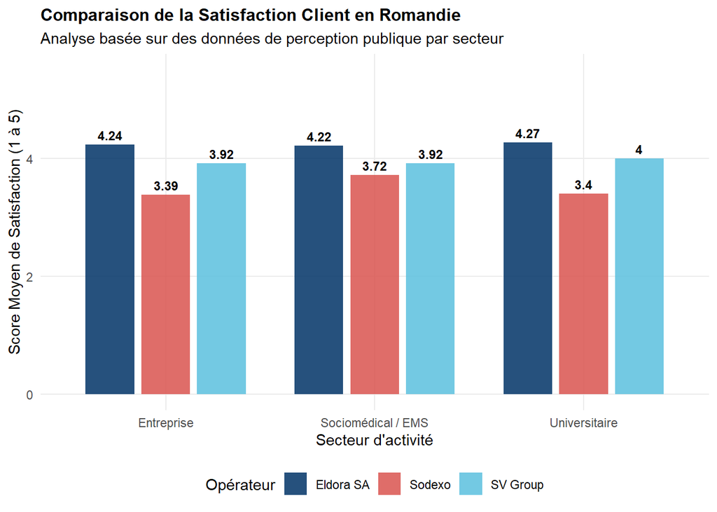

# 5. Conclusion et Apport de Valeur Opérationnelle

**Vision Managériale :** *Fort de plus de 20 ans d’expérience en cuisine et gestion en Suisse, et enrichi par une formation en management stratégique orienté client (Basque Culinary Center) ainsi qu’en *Data Science* (EPFL), mon objectif est de traduire ces indicateurs de satisfaction en actions concrètes sur le terrain : optimisation des flux de production, pilotage rigoureux du *food cost* et réduction du gaspillage, tout en plaçant l’expérience et le bien-être du convive au centre de chaque décision opérationnelle*